# Preparing GP2 v10 clinical data for GWAS

# Add principal components

## Load the prepared clinical data file from my results

- The file is named v10_EUR_YOPD_CO.csv

```r
RESULTS_PATH <- fs::path_home('my_results_R/')
```

```r
#Read in the data
EUR_YOPD_CO_DATA_PATH <- fs::path(RESULTS_PATH, 'v10_EUR_YOPD_CO.csv')
clinical_df <- read_csv(EUR_YOPD_CO_DATA_PATH)
print(dim(clinical_df))
```

## Read in the GP2 v10 Principal components eigenval and eigenvec files for EUR ancestry

```r
#Read in the eigenval file
#Obs, the file does not have a header
PC_EUR_eigenval_PATH <- fs::path(REL10_PATH, 'raw_genotypes/EUR/EUR_release10_vwb.eigenval')
PC_EUR_eigenval_df <- read_csv(PC_EUR_eigenval_PATH, show_col_types = FALSE, col_names = FALSE)
head(PC_EUR_eigenval_df, 10)
print("show dimensions of eigenval")
dim(PC_EUR_eigenval_df)
```

```r
#Read in the eigenvec file
PC_EUR_eigenvec_PATH <- fs::path(REL10_PATH, 'raw_genotypes/EUR/EUR_release10_vwb.eigenvec')
PC_EUR_eigenvec_df <- read_tsv(PC_EUR_eigenvec_PATH, show_col_types = FALSE)#
colnames(PC_EUR_eigenvec_df, 10)
print("show dimensions of eigenvec")
dim(PC_EUR_eigenvec_df)
```

## Make a scree plot from the eigenval file

```
[1] "show the eigenval file"
# A tibble: 10 × 1
      X1
   <dbl>
 1 79.6
 2 31.3
 3 15.4
 4 12.6
 5 11.6
 6  8.94
 7  8.87
 8  7.86
 9  7.39
10  7.31
[1] "show the eigenval2 file"
# A tibble: 10 × 3
   Eigenvalues    PC VarianceExplained
         <dbl> <dbl>             <dbl>
 1       79.6      1             41.7
 2       31.3      2             16.4
 3       15.4      3              8.07
 4       12.6      4              6.59
 5       11.6      5              6.09
 6        8.94     6              4.68
 7        8.87     7              4.65
 8        7.86     8              4.12
 9        7.39     9              3.87
10        7.31    10              3.83
```

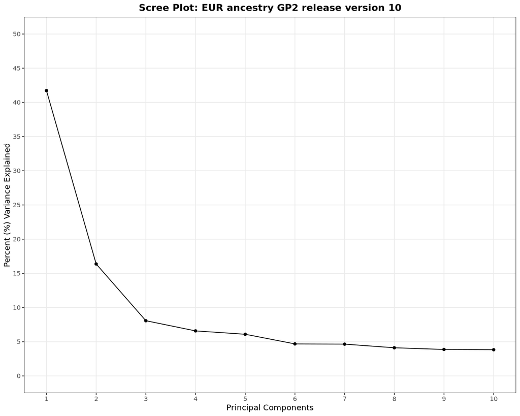

```r
# Rename and display the eigenval df
print("show the eigenval file")
eigenval <- PC_EUR_eigenval_df
print(eigenval)

# Update column names
colnames(eigenval)[1] <- "Eigenvalues"
eigenval$PC <- as.numeric(rownames(eigenval))
eigenval$VarianceExplained <- eigenval$Eigenvalues/sum(eigenval$Eigenvalues)*100

# Keeping only the first 10 PCs - there are only 10 eigenvals
eigenval2 <- head(eigenval,10)

print("show the eigenval2 file")
print(eigenval2)

# Generating the plot
scree <- ggplot(data = eigenval2, aes(x = PC, y = VarianceExplained)) +
  geom_line() +
  geom_point() +
  theme_bw() +
  theme(panel.grid.minor = element_blank()) +
  scale_x_continuous(name = "Principal Components", breaks = seq(0,10,1), limits = c(NA,10)) +
  scale_y_continuous(name = "Percent (%) Variance Explained", breaks = seq(0,50,5), limits = c(0,50)) +
  ggtitle("Scree Plot: EUR ancestry GP2 release version 10") +
  theme(plot.title = element_text(hjust = 0.5, face = "bold"))
print(scree)
```

## Merge PCA eigenvectors with the clinical data file to prepare the covariate file

```r
#Merge clinical data with eigenvec (PC_EUR_eigenvec_df) file to get Pc1-10

#Rename IID in eigenvec file to GP2ID before merging
PC_EUR_eigenvec_df <- PC_EUR_eigenvec_df %>% rename(GP2ID = IID)

#Merge PCA and clinical data
clinical_filtered_for_gwas = merge(clinical_df,PC_EUR_eigenvec_df,by="GP2ID")
print("show dim for clinical_filtered_for_gwas")
dim(clinical_filtered_for_gwas)
```

## Plot PC1 vs PC2 and inspect different variables

- This can be done for variables of interest. e.g. study, region for qc, sample_type etc.

```r
###Highlight baseline_GP2_phenotype_for_qc

# Create scatter plot with ggplot
plot1 <- ggplot(clinical_filtered_for_gwas, aes(x = PC1, y = PC2, color = baseline_GP2_phenotype_for_qc)) +
  geom_point() +
  labs(title = "clinical_filtered_for_gwas PC1 vs PC2") +
  theme_minimal()

# Print the plot
print(plot1)
```

[output not shown]

## Write the cleaned data file "clinical_PCA_filtered_for_gwas.csv " to a new csv-file and save at cloud environment

```r
disk_output_path <- fs::path_home('my_results_R/v10_clinical_data_and_PCA_filtered_for_gwas.csv')

# Write the filtered CSV file to the disk output path.
write_csv(clinical_filtered_for_gwas, disk_output_path)
print(str_glue('Wrote {disk_output_path}'))

# Read the new file and show the colnames to ensure that all variables are contained in the new file
disk_output_df <- read_csv(disk_output_path, show_col_types = FALSE)
print(colnames(disk_output_df))
```

# Generate the covariate file

## Load the filtered GP2 v10 clinical data file including PCs

- named v10_clinical_data_and_PCA_filtered_for_gwas.csv

```r
#Establish COVAR PATH and look at file

COVAR_DATA_PATH <- fs::path(RESULTS_PATH, 'v10_clinical_data_and_PCA_filtered_for_gwas.csv')

# Read the CSV file with specified column types (read in wgs_prune_reason as "character" to avoid parsing issues)
clinical_df <- read_csv(
  COVAR_DATA_PATH,
  col_types = cols(
    wgs_prune_reason = col_character()
  )
)

print(dim(clinical_df))
table(clinical_df$baseline_GP2_phenotype_for_qc)
```

### Modify the file

```r
#Rename GP2ID to IID to make it comaptible with PLINK 2
clinical_df <- clinical_df %>% rename(IID = GP2ID)
```

```r
#Make the covariate file - extract variables #FID, IID, biological_sex_for_qc, baseline_GP2_phenoype_for_qc, PC1-PC10

COVAR_start = clinical_df %>% select("#FID", "IID","biological_sex_for_qc", "baseline_GP2_phenotype_for_qc", "PC1","PC2","PC3","PC4","PC5","PC6","PC7","PC8","PC9","PC10")

head(COVAR_start, 10)
```

```r
#Change variables in "COVAR" to make them applicapble for PLINK 2

# Rename the column
COVAR_renamed <- COVAR_start %>% rename(FID = "#FID")
COVAR_renamed <- COVAR_renamed %>% rename(SEX = biological_sex_for_qc)
COVAR_renamed <- COVAR_renamed %>% rename(PHENO = baseline_GP2_phenotype_for_qc)

head(COVAR_renamed, 4)
```

```r
# Recode the SEX variable to make it compatible with PLINK2. male=1 and female=2, other = NA
#(PLINK 1 or M = male), (2 or F = female), 0 = missing, https://www.cog-genomics.org/plink/1.9/data)
COVAR_renamed$SEX <- ifelse(COVAR_renamed$SEX == "Male", 1, ifelse(COVAR_renamed$SEX == "Female", 2, 0))

#Recode the PHENO variable to make it compatible with PLINK 2
#(binary phenotype, 2(case)/1(control), https://www.cog-genomics.org/plink/1.9/input#pheno)
COVAR_renamed$PHENO <- ifelse(COVAR_renamed$PHENO == "Control", 1, ifelse(COVAR_renamed$PHENO == "PD", 2, 0))
head(COVAR_renamed, 10)
print("dim of COVAR_renamed")
print(dim(COVAR_renamed))
COVAR <- COVAR_renamed
```

```r
print("COVAR$PHENO")
table(COVAR$PHENO)
print("COVAR$SEX")
table(COVAR$SEX)
```

```
[1] "COVAR$PHENO"
```

```
   1    2
4635  608
```

```
[1] "COVAR$SEX"
```

```
   1    2
2498 2745
```

## Write the final COVAR df "COVAR" into a .txt file

```r
disk_output_path <- fs::path_home('my_results_R/v10_COVAR.txt')

# Write the .txt file to the disk output path.
fwrite(COVAR, file = disk_output_path, sep = "\t", row.names = FALSE, quote = FALSE)
print(str_glue('Wrote {disk_output_path}'))
```

## Provenance

Generate information about this notebook environment and the packages installed.

```r
date()
```

'Mon Aug 18 10:00:14 2025'

Installed libraries

**$platform**

**$version**

'R version 4.4.1 (2024-06-14)'

**$os**

'Debian GNU/Linux 11 (bullseye)'

**$system**

'x86_64, linux-gnu'

**$ui**

'X11'

**$language**

'(EN)'

**$collate**

'C.UTF-8'

**$ctype**

'C.UTF-8'

**$tz**

'Etc/UTC'

**$date**

'2025-08-18'

**$pandoc**

'2.9.2.1 @ /usr/bin/ (via rmarkdown)'

**$packages**

A packages_info: 83 × 11

[output not shown]

Number of cores:

```r
system('grep ^processor /proc/cpuinfo | wc -l', intern = TRUE) %>% print()
```

```
[1] "2"
```

Memory

```r
system('grep "^MemTotal:" /proc/meminfo', intern = TRUE) %>% print()
```

```
[1] "MemTotal:       13296348 kB"
```